# Simulation-based calibration checking in model development workflow

## 3.1 Fixing prior definition

To avoid declaring two priors for `beta[1]` we need to modify the last line of the `model` block to

```stan
target += normal_lpdf(beta[2:N_predictors] | 0, 1);
```

so the full model now is:

```r
code_logistic_fixed_prior <- root("sbc", "models/logistic_fixed_prior.stan")
```

```r
print_stan_file(code_logistic_fixed_prior)
```

```stan
data {
  int<lower=0> N_obs;
  array[N_obs] int<lower=0, upper=1> y;
  int<lower=1> N_predictors;
  matrix[N_obs, N_predictors] X;
}
parameters {
  vector[N_predictors] beta;
}
model {
  target += bernoulli_logit_lpmf(y | X * beta);
  target += normal_lpdf(beta[1] | 0, 2);
  target += normal_lpdf(beta[2:N_predictors] | 0, 1);
}
```

```r
model_logistic_fixed_prior <- cmdstan_model(code_logistic_fixed_prior)
backend_logistic_fixed_prior <- SBC_backend_cmdstan_sample(model_logistic_fixed_prior, chains = 2)
```

The results for ten simulations are:

```r
results_logistic_fixed_prior_10 <- compute_SBC(
  datasets_logistic_merged_intercept_10,
  backend_logistic_fixed_prior,
  dquants = logistic_merged_intercept_loglik_dq,
  cache_mode = "results",
  cache_location = file.path(cache_dir, "logistic_fixed_prior_10"))
```

```
Results loaded from cache file 'logistic_fixed_prior_10'
```

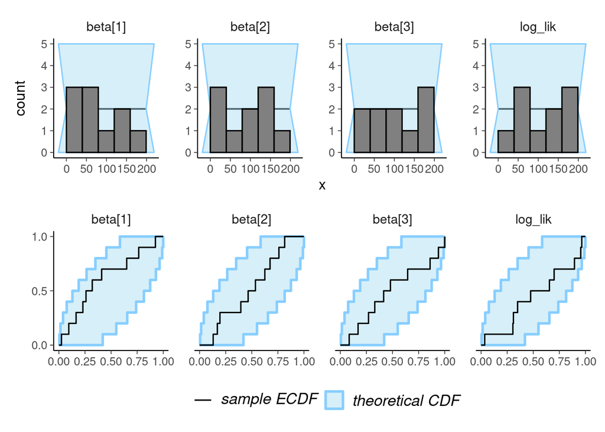

Figure 13: Rank histogram (top) and ECDF plot (bottom) for the first 10 simulations of the logistic submodel with fixed prior.

```r
logistic_fixed_prior_ranks <- plot_rank_hist(results_logistic_fixed_prior_10, facet_args = list(nrow = 1))
logistic_fixed_prior_ecdf <- plot_ecdf(results_logistic_fixed_prior_10, facet_args = list(nrow = 1)) + theme(legend.position = "bottom")
logistic_fixed_prior_ranks / logistic_fixed_prior_ecdf
```

No obvious problem, so let’s add 200 additional simulations:

```r
set.seed(32464655)
datasets_logistic_merged_intercept_200 <- generate_datasets(generator_logistic_merged_intercept, 200)
results_logistic_fixed_prior_200 <- compute_SBC(
  datasets_logistic_merged_intercept_200,
  backend_logistic_fixed_prior,
  keep_fits = FALSE,
  dquants = logistic_merged_intercept_loglik_dq,
  cache_mode = "results",
  cache_location = file.path(cache_dir, "logistic_fixed_prior_200"))
```

```
Results loaded from cache file 'logistic_fixed_prior_200'
```

```
 - 2 (1%) fits had maximum Rhat > 1.01. Maximum Rhat was 1.01.
```

```
Not all diagnostics are OK.
You can learn more by inspecting $default_diagnostics, $backend_diagnostics
and/or investigating $outputs/$messages/$warnings for detailed output from the backend.
```

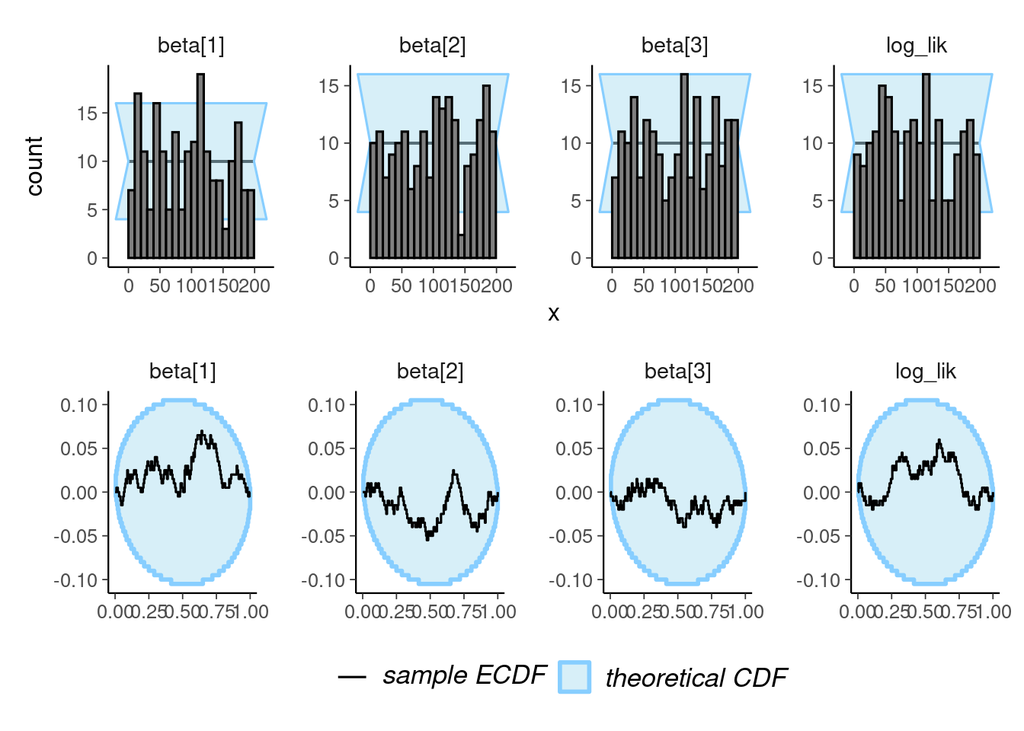

Figure 14: Rank histogram (top) and ECDF plot (bottom) for the full 200 simulations of the logistic submodel with merged intercept.

```r
logistic_fixed_prior_ranks <- plot_rank_hist(results_logistic_fixed_prior_200, facet_args = list(nrow = 1))
logistic_fixed_prior_ecdf <- plot_ecdf_diff(results_logistic_fixed_prior_200, facet_args = list(nrow = 1)) + theme(legend.position = "bottom")
logistic_fixed_prior_ranks / logistic_fixed_prior_ecdf
```

Looking good! We can also check that we are indeed able to learn the model parameters with reasonable precision from the data.

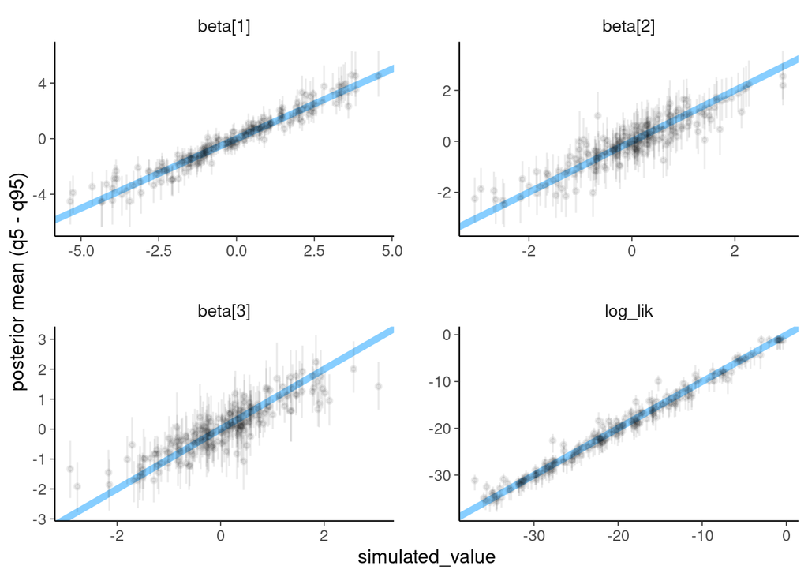

Figure 15: Simulated and estimated values for the 200 simulations of the logistic submodel with merged intercept.

```r
plot_sim_estimated(results_logistic_fixed_prior_200)
```

# 4 Full model

We are finally ready to make a first attempt at the full model:

```r
code_combined <- root("sbc", "models/combined_first.stan")
```

```r
print_stan_file(code_combined)
```

```stan
data {
  int<lower=0> N_obs;
  array[N_obs] int y;
  int<lower=1> N_predictors;
  matrix[N_obs, N_predictors] X;
}
parameters {
  ordered[2] mu;
  vector[N_predictors] beta;
}
model {
  vector[N_obs] theta = inv_logit(X * beta);
  for(n in 1:N_obs) {
    target += log_mix(theta[n],
                      poisson_log_lpmf(y[n] | mu[1]),
                      poisson_log_lpmf(y[n] | mu[2]));
  }
  target += normal_lpdf(mu | 3, 1);
  target += normal_lpdf(beta[1] | 0, 2);
  target += normal_lpdf(beta[2:N_predictors] | 0, 1);
}
```

```r
model_combined <- cmdstan_model(code_combined)
backend_combined <- SBC_backend_cmdstan_sample(model_combined)
```

And this is our generator for the full model:

```r
generator_func_combined <- function(N_obs, N_predictors) {
  # If the priors for all components of an ordered vector are the same
  # then just sorting the result of a generator is enough to create
  # a valid draw from the ordered vector prior
  mu <- sort(rnorm(2, 3, 1))
  beta <- c(rnorm(1, 0, 2), rnorm(N_predictors - 1, 0, 1))
  X <- matrix(rnorm(N_predictors * N_obs, 0, 1), nrow = N_obs, ncol = N_predictors)
  X[, 1] <- 1 # Intercept
  y <- array(NA_real_, N_obs)
  for (n in 1:N_obs) {
    linpred <- 0
    for (p in 1:N_predictors) {
      linpred <- linpred + X[n, p] * beta[p]
    }
    theta <- plogis(linpred)
    if (runif(1) < theta) {
      y[n] <- rpois(1, exp(mu[1]))
    } else {
      y[n] <- rpois(1, exp(mu[2]))
    }
  }
  list(variables = list(beta = beta,
                        mu = mu),
    generated = list(N_obs = N_obs,
                     N_predictors = N_predictors,
                     y = y,
                     X = X))
}
generator_combined <- SBC_generator_function(generator_func_combined, N_obs = 50, N_predictors = 3)
```

We are confident (and the fits are fast anyway), so we start with 200 simulations:

```r
set.seed(5749955)
dataset_combined <- generate_datasets(generator_combined, 200)

results_combined <- compute_SBC(dataset_combined,
                                backend_combined,
                                keep_fits = FALSE,
                                cache_mode = "results",
                                cache_location = file.path(cache_dir, "combined"))
```

```
Results loaded from cache file 'combined'
```

```
 - 51 (26%) fits had divergences. Maximum number of divergences was 234.
```

```
 - 1 (0%) fits had steps rejected. Maximum number of steps rejected was 1.
```

```
 - 14 (7%) fits had maximum Rhat > 1.01. Maximum Rhat was 1.156.
```

```
 - 28 (14%) fits had tail ESS / maximum rank < 0.5. Minimum tail ESS / maximum rank was 0.04. This potentially skews the rank statistics.
    If the fits look good otherwise, increasing `thin_ranks` (via recompute_SBC_statistics)
   or number of posterior draws (by refitting) might help.
```

```
Not all diagnostics are OK.
You can learn more by inspecting $default_diagnostics, $backend_diagnostics
and/or investigating $outputs/$messages/$warnings for detailed output from the backend.
```

We get some amount of divergent transitions, but the ranks look pretty good:

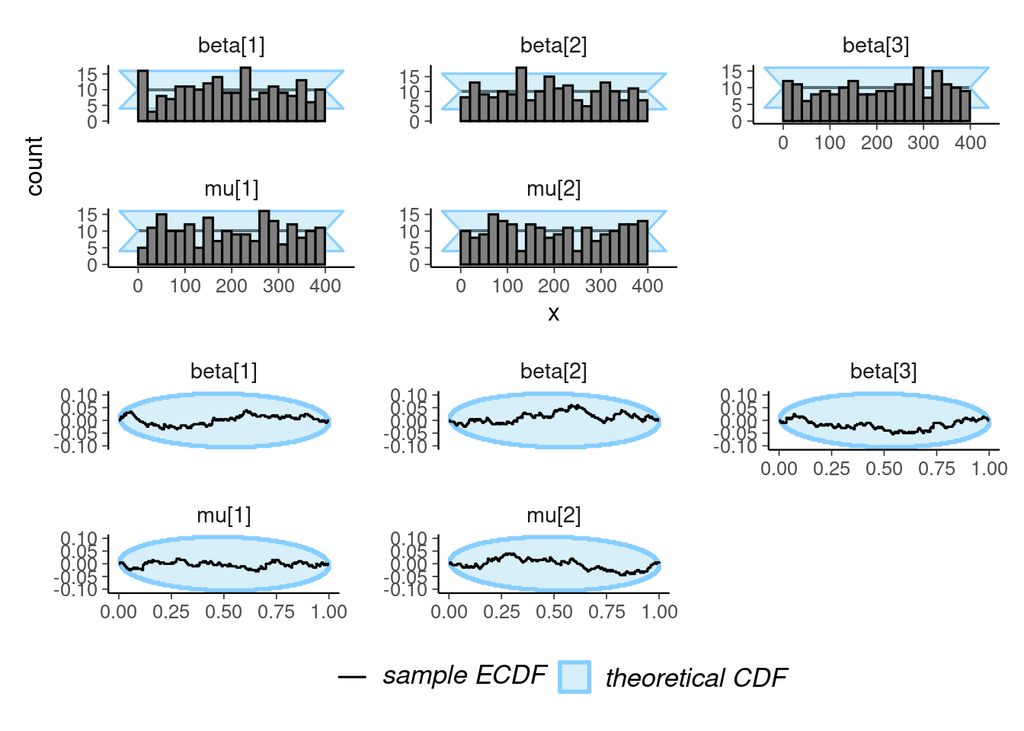

```r
combined_ranks <- plot_rank_hist(results_combined)
combined_ecdf <- plot_ecdf_diff(results_combined) + theme(legend.position = "bottom")
combined_ranks / combined_ecdf
```

Indeed it seems the model works pretty well.

## 4.1 Adding rejection sampling

As done previously, we could just exclude the fits that had divergences, but just to complete our tour of possibilities, we’ll show one more option to dealing with this type of problem.

The general idea is that although we might not want to or be able to express our prior belief about the model (here that the two mixture components are distinct) by priors on model parameters, we still may be able to express our prior belief about the data itself.

And it turns out that if we remove simulations that don’t meet a certain condition imposed on the observed data, the implied prior on parameters becomes an additive constant and we can use exactly the same model to fit only the non-rejected simulations. Note that this does not hold if we rejected simulations based on some unobserved variables - for more details see the [`rejection_sampling`](https://hyunjimoon.github.io/SBC/articles/rejection_sampling.html) vignette.

The main advantage is that if we can do this, we can avoid wasting computation on fitting data that would likely produce divergences anyway. The downside is that it means we no longer have a guarantee the model works for non-rejected data, so we need to check if the data we want to analyze would not be rejected by our criterion.

All the divergences are for low Fano factors - this is the histogram of Fano factor for diverging fits:

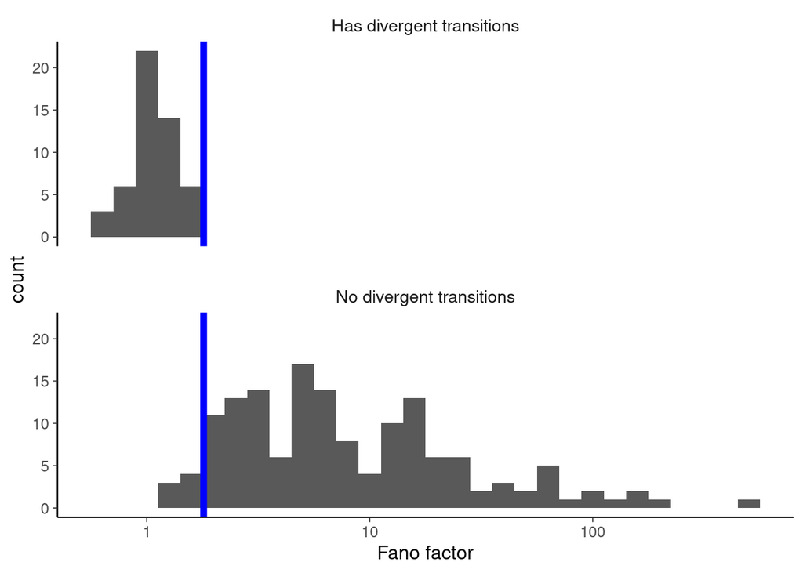

Figure 17: Fano factors of fits with/without divergent transitions.

```r
fanos <- vapply(dataset_combined$generated,
                function(dataset) { var(dataset$y) / mean(dataset$y) },
                FUN.VALUE = 0)
fanos_df <- data.frame(fano = fanos,
                       type = ifelse(results_combined$backend_diagnostics$n_divergent > 0,
                                      "Has divergent transitions", "No divergent transitions"))
fano_threshold <- 1.8
fanos_plot <-  ggplot(fanos_df, aes(x = fano)) +
  geom_histogram(binwidth = 0.1) +
  geom_vline(xintercept = fano_threshold, color = "blue", linewidth = 2) +
  scale_x_log10("Fano factor") + facet_wrap(~type, ncol = 1)
fanos_plot
```

So what we’ll do is that we’ll reject any simulation where the observed data have Fano factor < 1.8. In practice a simple way to implement this is to wrap our generator code in a loop and break from the loop only when the generated data meet our criteria (i.e. is not rejected). This is our code:

```r
generator_func_combined_reject <- function(N_obs, N_predictors) {
  if (N_obs < 5) {
    stop("Too low N_obs for this simulator")
  }
  repeat {
    # If the priors for all components of an ordered vector are the same
    # then just sorting the result of a generator is enough to create
    # a valid draw from the ordered vector prior
    mu <- sort(rnorm(2, 3, 1))
    beta <- c(rnorm(1, 0, 2), rnorm(N_predictors - 1, 0, 1))
    X <- matrix(rnorm(N_predictors * N_obs, 0, 1), nrow = N_obs, ncol = N_predictors)
    X[, 1] <- 1 # Intercept
    y <- array(NA_real_, N_obs)
    for (n in 1:N_obs) {
      linpred <- 0
      for (p in 1:N_predictors) {
        linpred <- linpred + X[n, p] * beta[p]
      }
      theta <- plogis(linpred)
      if (runif(1) < theta) {
        y[n] <- rpois(1, exp(mu[1]))
      } else {
        y[n] <- rpois(1, exp(mu[2]))
      }

    }
    if (var(y) / mean(y) > fano_threshold) {
      break;
    }
  }
  list(variables = list(beta = beta,
                        mu = mu),
       generated = list(N_obs = N_obs,
                        N_predictors = N_predictors,
                        y = y,
                        X = X))
}
generator_combined_reject <-
  SBC_generator_function(generator_func_combined_reject, N_obs = 50, N_predictors = 3)
```

We’ll once again fit our model to 200 simulations:

```r
set.seed(44685226)
dataset_combined_reject <- generate_datasets(generator_combined_reject, 200)

results_combined_reject <- compute_SBC(dataset_combined_reject,
                                       backend_combined,
                                       keep_fits = FALSE,
                                       cache_mode = "results",
                                       cache_location = file.path(cache_dir, "combined_reject"))
```

```
Results loaded from cache file 'combined_reject'
```

```
 - 1 (0%) fits had divergences. Maximum number of divergences was 1.
```

```
Not all diagnostics are OK.
You can learn more by inspecting $default_diagnostics, $backend_diagnostics
and/or investigating $outputs/$messages/$warnings for detailed output from the backend.
```

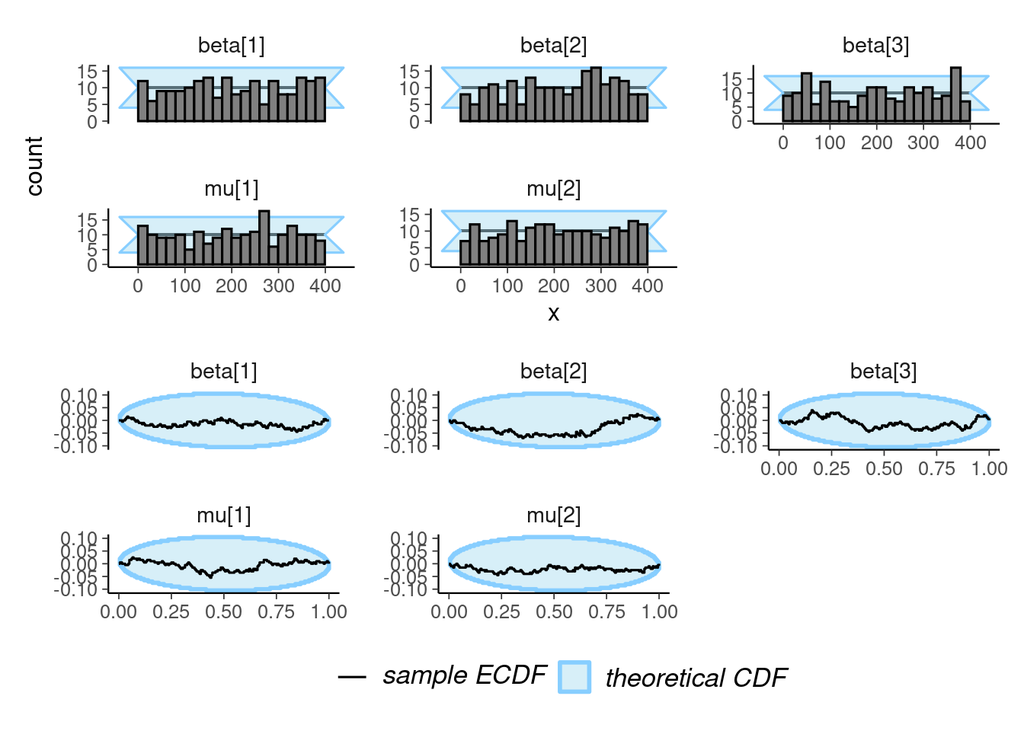

Figure 18: Rank histogram (top) and ECDF difference plot (bottom) for the full model after rejecting datasets with low Fano factor.

```r
combined_ranks <- plot_rank_hist(results_combined_reject)
combined_ecdf <- plot_ecdf_diff(results_combined_reject) + theme(legend.position = "bottom")
combined_ranks / combined_ecdf
```

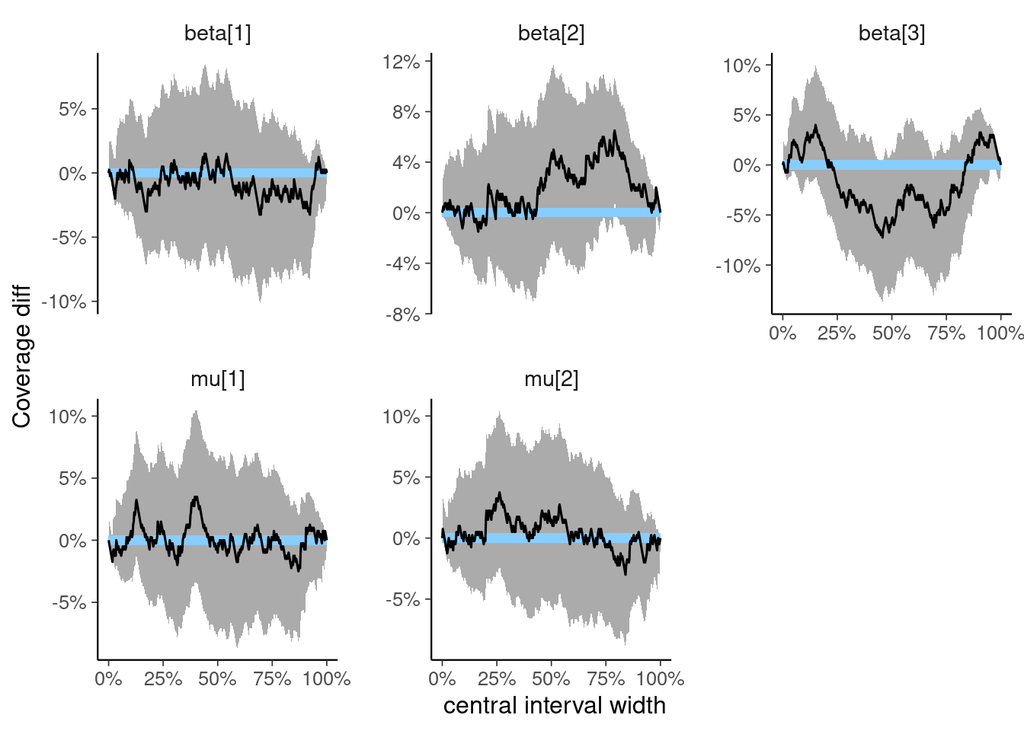

Figure 19: Difference between actual and expected coverage of central posterior intervals for the full model.

```r
plot_coverage_diff(results_combined_reject)
```

Below we show the uncertainty for two variables and some widths of central posterior intervals numerically:

```r
stats_subset <- results_combined_reject$stats[
  results_combined_reject$stats$variable %in% c("beta[1]", "mu[1]"), ]
empirical_coverage(stats_subset, c(0.25, 0.5, 0.9, 0.95))
```

```
# A tibble: 8 × 6
  variable width width_represented ci_low estimate ci_high
  <chr>    <dbl>             <dbl>  <dbl>    <dbl>   <dbl>
1 beta[1]   0.25              0.25   0.20     0.26    0.32
2 beta[1]   0.5               0.5    0.44     0.50    0.57
3 beta[1]   0.9               0.9    0.82     0.88    0.91
4 beta[1]   0.95              0.95   0.92     0.96    0.98
5 mu[1]     0.25              0.25   0.20     0.26    0.32
6 mu[1]     0.5               0.5    0.42     0.49    0.56
7 mu[1]     0.9               0.9    0.84     0.90    0.93
8 mu[1]     0.95              0.95   0.91     0.95    0.97
```

Maybe we think the remaining uncertainty is too big, so we’ll run 300 more simulations, just to be sure:

```r
set.seed(1395367854)
dataset_combined_reject_more <- generate_datasets(generator_combined_reject, 300)
results_combined_reject_more <- bind_results(
  results_combined_reject,
  compute_SBC(dataset_combined_reject_more,
              backend_combined,
              keep_fits = FALSE,
              cache_mode = "results",
              cache_location = file.path(cache_dir, "combined_reject_more")))
```

```
Results loaded from cache file 'combined_reject_more'
```

```
 - 1 (0%) fits had divergences. Maximum number of divergences was 2.
```

```
 - 2 (1%) fits had steps rejected. Maximum number of steps rejected was 1.
```

```
Not all diagnostics are OK.
You can learn more by inspecting $default_diagnostics, $backend_diagnostics
and/or investigating $outputs/$messages/$warnings for detailed output from the backend.
```

We get some very small number of problematic fits, which we can ignore in this volume (but probably more aggressive rejection sampling would remove those as well).

Our plots and coverage are now pretty decent:

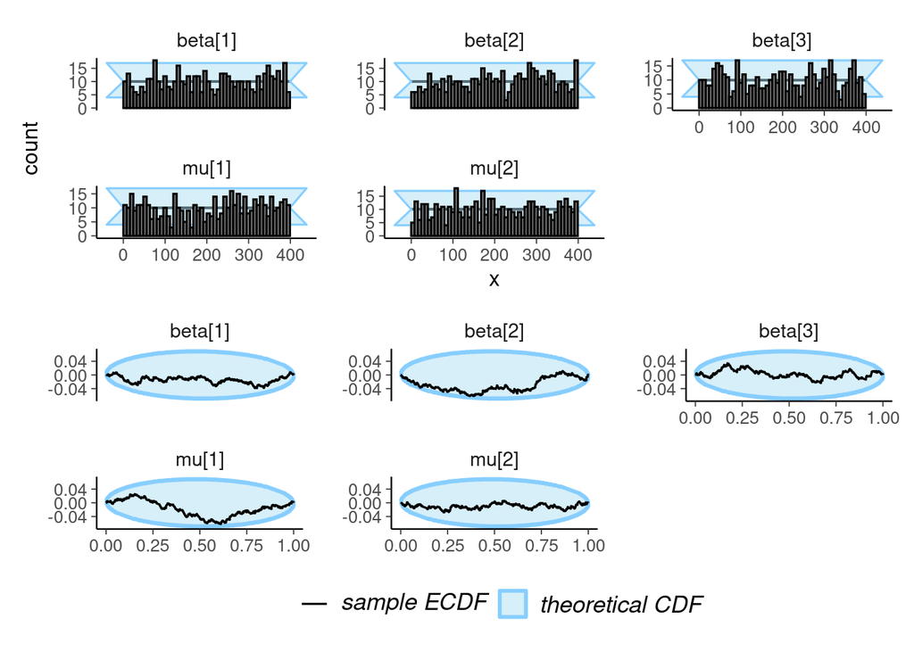

Figure 20: Rank histogram (top) and ECDF difference plot (bottom) after adding more simulations for the complete model.

```r
combined_ranks <- plot_rank_hist(results_combined_reject_more)
combined_ecdf <- plot_ecdf_diff(results_combined_reject_more) + theme(legend.position = "bottom")
combined_ranks / combined_ecdf
```

[output not shown]

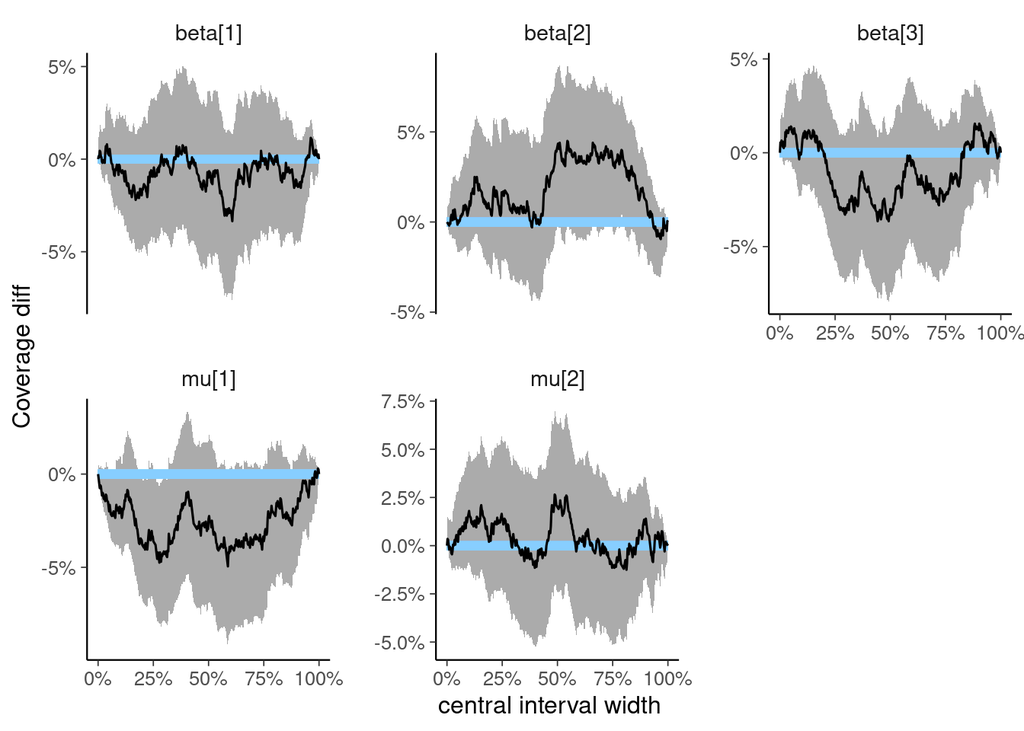

Figure 21: Difference between actual and expected coverage of central posterior intervals for the full model, including more simulations.

```r
combined_reject_coverage <- plot_coverage_diff(results_combined_reject_more)
combined_reject_coverage

stats_subset <- results_combined_reject_more$stats[
  results_combined_reject_more$stats$variable %in% c("beta[1]", "mu[2]"), ]
empirical_coverage(stats_subset, c(0.25, 0.5, 0.9, 0.95))
```

This actually shows a limitation of the coverage results - for `mu[1]` the approximate CI for coverage excludes exact calibration for a bunch of intervals, but above we see that the more trustworthy `plot_ecdf_diff` is not showing a problem (although there is some tendency towards slight underdispersion).

Still, this might warrant further investigation if small discrepancies in `mu` are considered important, if we are interested only in the `beta` coefficients, we can stay assured that their calibration is pretty good. We give you our word that we ran additional simulations and the discrepancy disappears.

Finally, we can also use this simulation exercise to understand what would we be likely to learn from an experiment matching the simulations (50 observations, 3 predictors) and plot the true values (simulated by the generator) against estimated mean + 90% posterior credible interval:

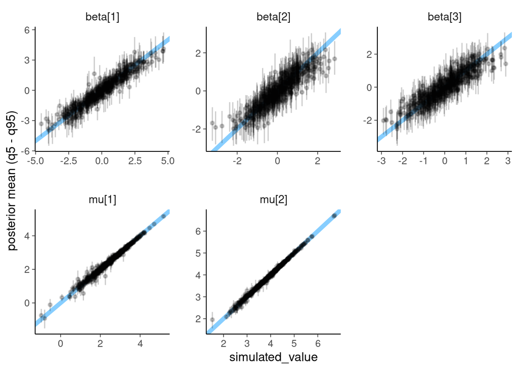

Figure 22: Simulated and estimated values for the comibned model and more simulations.

```r
sim_estimated_final <- plot_sim_estimated(results_combined_reject_more, alpha = 0.2)
sim_estimated_final
```

We see that we get very precise information about `mu` and a decent picture about all `beta` elements, but the remaining uncertainty is large. We could for example compute the probability that the posterior 90% interval for `beta[2]` excludes zero, i.e. that we learn something about the sign of the association with a continuous predictor:

```r
stats_beta2 <-
  results_combined_reject_more$stats[
    results_combined_reject_more$stats$variable == "beta[2]",]
mean(sign(stats_beta2$q5) == sign(stats_beta2$q95))
```

```
[1] 0.506
```

Turns out the probability is only around 50%. Depending on your aims, this might be a reason to plan for a larger sample size!

# 5 Take home message

There are couple lessons I hope this exercise showed: First, building models you can trust is hard work and it is very easy to make mistakes. Despite the models presented here being relatively simple, diagnosing the problems in them was not straightforward and required non-trivial background knowledge. For this reason, moving in small steps during model development is crucial and can save you time as diagnosing the same problems in a 300-line Stan model with 50 parameters can be basically impossible.

We also hope we convinced you that the SBC package lets you get high-quality information from your simulation efforts and not only diagnose problems but also get some sort of assurance in the end that your model is at least pretty close to your simulator.

# References

Modrák, Martin, Angie H. Moon, Shinyoung Kim, Paul Bürkner, Niko Huurre, Kateřina Faltejsková, Andrew Gelman, and Aki Vehtari. 2025. “Simulation-Based Calibration Checking for Bayesian Computation: The Choice of Test Quantities Shapes Sensitivity.” *Bayesian Analysis* 20 (2): 461–88.

# Licenses

- Code © 2022–2026, Martin Modrák, licensed under BSD-3.
- Text © 2022–2026, Martin Modrák, licensed under CC-BY-NC 4.0.